# HW6

Cheng Huang 2658312

19 October 2018

# Rejection Sampling

## Draw sample from g

Pseudo - code  
(1)draw U ~ U(0,1)  
(2)if $U < \frac{2\Gamma(\theta)}{2\Gamma(\theta)+\Gamma(\theta+1/2)}$, draw X ~ Gamma($\theta,1$)  
else draw X ~ Gamma($\theta+1/2, 1$)  
(3)return X

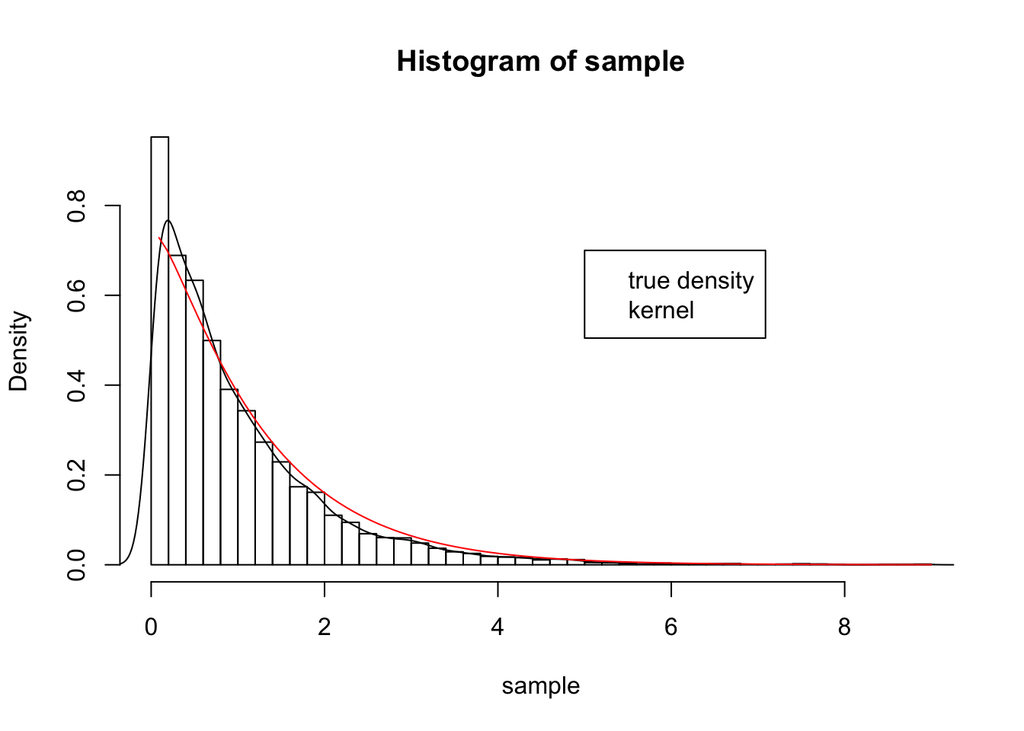

```r
knitr::opts_chunk$set(echo = TRUE)
require(data.table)

sample.g <- function(n, theta){
  u <- runif(n)
  g1 <- rgamma(n, shape = theta, rate = 1)
  g2 <- rgamma(n, shape = theta + 0.5, rate = 1)
  weight1 <- 2 * gamma(theta) / (2 * gamma(theta) + gamma(theta + 0.5))
  weight2 <- 1 - weight1
  if(u < weight1){
    return(g1[u < weight1])
  }else{
    return(g2[u >= weight1])
  }
}
sample <- sample.g(10000, 1)

true.dens <- function(x){
   C <- 1 / (2 * gamma(1) + gamma(1 + 0.5))
   return( C * (2 + x^{1 - 1/2}) * exp(1)^{-x})
}
hist(sample, prob=TRUE, breaks = 50)
lines(density(sample))
curve(true.dens(x), add = T, col = 'red')
?legend
legend(5, 0.7, legend= c("true density", "kernel"), col=c("red", "black"))
```

## rejection sampling

First find minimal M such that $f(x) \le M g(x)$.
$$M = sup_{x>0}\frac{f(x)}{g(x)}=sup_{x>0}\frac{\sqrt{4+x}x^{\theta-1}e^{-x}}{C(2x^{\theta-1}+x^{\theta-1/2})e^{-x}}=sup_{x>0}\frac{\sqrt{4+x}}{C\sqrt{x}}=\frac{1}{C}$$
Therefore the criterion for accepting a sample is
$$U \le \frac{\sqrt(x + 4)}{2 + \sqrt(x)}$$
Pseudo - code
(1)draw U ~ U(0,1), X ~ g(x)
(2)if $U \le \frac{f(x)}{Mg(x)}$, return X else go back to (1)
(3)return X

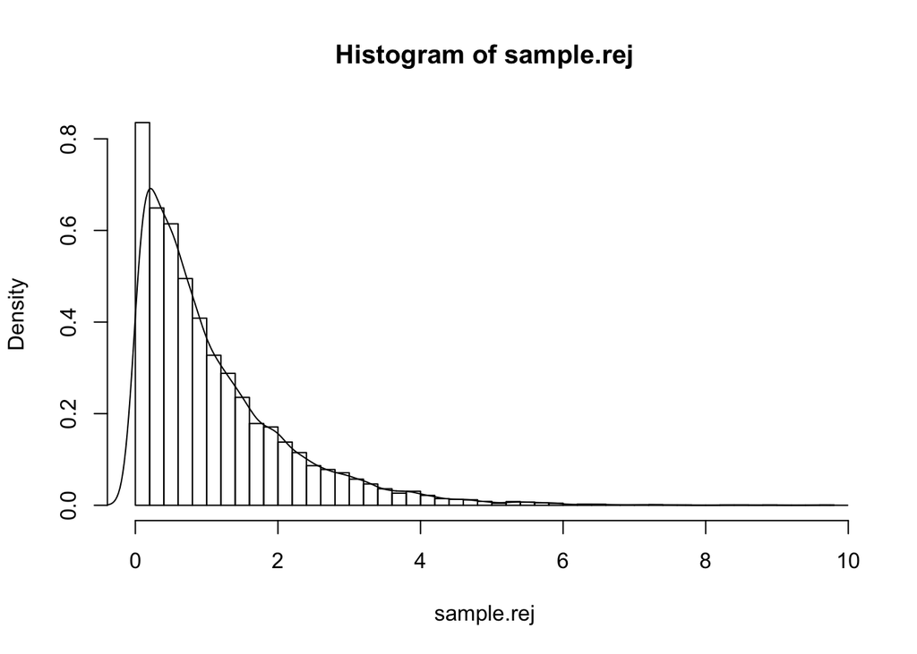

```r
knitr::opts_chunk$set(echo = TRUE)
require(data.table)

rejection.g <- function(n, theta){
  iter <- 1
  sample <- rep(0,n)
  while (iter <= n) {
    u <- runif(1)
    x <- sample.g(1, theta)
    if(u <= sqrt(4 + x)/(2 + sqrt(x))){
      sample[iter] <- x
      iter <- iter +1
    }
  }
  sample
}
sample.rej <- rejection.g(10000, 1)
hist(sample.rej, prob = TRUE, breaks = 50)
lines(density(sample.rej))
```

# Mixture Proposal

## Mixture of Beta

$f(x) \propto \frac{x^{\theta-1}}{1+x^2} + \sqrt{2 + x^2}(1-x)^{\beta-1} \le x^{\theta-1}+\sqrt{3}(1-x)^{\beta-1}$, therefore choose $g(x)=\lambda Beta(\theta,1) + (1-\lambda)Beta(1, \beta) = \lambda \theta x^{\theta-1}+(1-\lambda)\beta (1-x)^{\beta-1}$.
Choose $\lambda = 1/2$,
$$g(x) = \frac{\theta}{2} x^{\theta-1}+\frac{\beta}{2} (1-x)^{\beta-1}$$
Therefore,
$$f(x)\le x^{\theta-1}+\sqrt{3}(1-x)^{\beta-1} \le \alpha g(x) = \frac{M \theta}{2}x^{\theta-1} +\frac{M \beta}{2}(1-x)^{\beta-1}$$
This Inequality holds when $M = max(2/\theta,2\sqrt{3}/\beta)$.

Select $\theta = 2, \beta = 1, M = 2\sqrt{3}$. Then $Mg(x) = 2\sqrt{3}x+\sqrt{3}$,The sample is accepted when $U \le \frac{f(X)}{Mg(X)}=\frac{\frac{x}{1+x^2} + \sqrt{2 + x^2}}{2\sqrt{3}x+\sqrt{3}}$.  
Pseudo - code  
(1)draw U ~ U(0,1), X ~ g(x)  
(2)if $U \le \frac{f(x)}{Mg(x)}$, return X else go back to (1)  
(3)return X

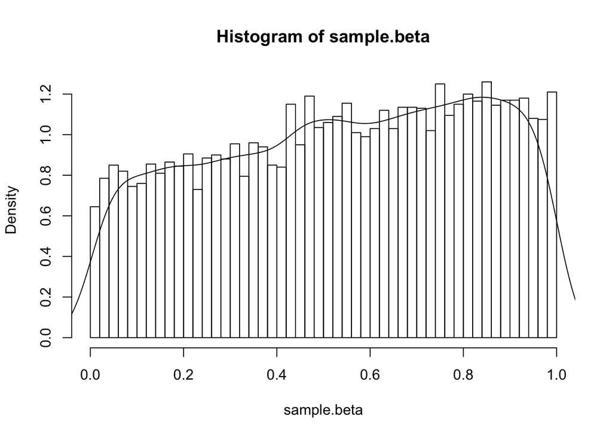

```r
knitr::opts_chunk$set(echo = TRUE)
require(data.table)
sample.beta <- function(n){
  u <- runif(n)
  g1 <- rbeta(n, shape1 = 2, shape2 = 1)
  g2 <- rbeta(n, shape1 = 1, shape2 = 1)
  weight1 <- 1/2
  weight2 <- 1 - weight1
  if(u < weight1){
    return(g1[u < weight1])
  }else{
    return(g2[u >= weight1])
  }
}
rejection.beta <- function(n, theta){
  iter <- 1
  sample <- rep(0,n)
  while (iter <= n) {
    u <- runif(1)
    x <- sample.beta(1)
    if(u <= (x/(1 + x^2) + sqrt(2 + x^2))/(2 * sqrt(3) * x + sqrt(3))){
      sample[iter] <- x
      iter <- iter +1
    }
  }
  sample
}
sample.beta <- rejection.beta(10000)
hist(sample.beta, prob = TRUE, breaks = 50)
lines(density(sample.beta))
```

## Dealing with two components using Beta

It is shown from above that for $x \in [0,1]$
$$f_1(x) = \frac{x^{\theta-1}}{1+x^2} \le x^{\theta-1}$$
So define $g_1(x)=\theta x^{\theta-1}$, such that
$$f_1(x)= \frac{x^{\theta-1}}{1+x^2} \le x^{\theta-1}\le M_1g_1(x)=M_1\theta x^{\theta-1}$$
So, the minimal of $M_1$ is $1/\theta$. So Criterion for accepting a sample is $U \le \frac{f_1(x)}{M_1g_1(x)}=\frac{1}{1+x^2}$
For the second component,
$$f_2(x) = \sqrt{2 + x^2}(1-x)^{\beta-1} \le \sqrt{3}(1-x)^{\beta-1}$$
So define $g_2(x)=\beta (1-x)^{\beta-1}$, such that
$$f_2(x)= \sqrt{2 + x^2}(1-x)^{\beta-1} \le \sqrt{3}(1-x)^{\beta-1}\le M_2g_2(x)=M_2\beta (1-x)^{\beta-1}$$
So, the minimal of $M_1$ is $\sqrt{3}/\beta$. So Criterion for accepting a sample is $U \le \frac{f_2(x)}{M_2g_2(x)}=\sqrt{\frac{2+x^2}{3}}$

Pseudo - code  
(1)draw $U \sim U(0,1)$  
(2)if $U \le \frac{M_1}{M_1+M_2}$, draw $U_1 \sim U(0,1), X_1 \sim g_1(x)$  
(3)if $U_1 \le \frac{f_1(x)}{M_1g_1(x)}$, return $X_1$ else go back to (2)  
(4)if $U > \frac{M_1}{M_1+M_2}$, draw $U_2 \sim U(0,1), X_2 \sim g_2(x)$  
(5)if $U_2 \le \frac{f_2(x)}{M_2g_2(x)}$, return $X_2$ else go back to (4)

Select $\theta = 2, \beta = 1$.

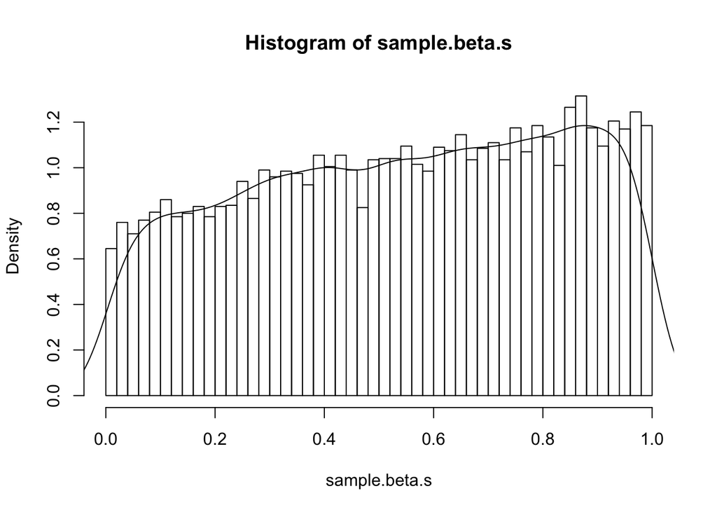

```r
knitr::opts_chunk$set(echo = TRUE)
require(data.table)
sample.beta.s <- function(n){
  iter <- 1
  sample <- rep(0,n)
  u <- runif(n)
  M1 <- 1/2
  M2 <- sqrt(3)
  weight1 <- M1/(M1 + M2)
  while (iter <= n) {
    if(u[iter] < weight1){
      u1 <- runif(1)
      g1 <- rbeta(1, shape1 = 2, shape2 = 1)
      if(u1 <= 1/(1+g1^2)){
        sample[iter] <- g1
        iter <- iter +1
       }
    }else{
      u2 <- runif(1)
      g2 <- rbeta(n, shape1 = 1, shape2 = 1)
      if(u2 <= sqrt((2+g2^2)/3)){
        sample[iter] <- g2
        iter <- iter +1
       }
    }
  }
  sample
}

sample.beta.s <- sample.beta.s(10000)
hist(sample.beta.s, prob = TRUE, breaks = 50)
lines(density(sample.beta.s))
```

# Reference

[jun-yan/stat-5361]https://github.com/jun-yan/stat-5361